# Graphing using ggplot

ENVS475: Experimental Analysis and Design

December, 2022

## About

This lab will introduce you to the `ggplot2` package in R. This is a powerful and flexible package which is capable of producing publication quality grpahics.

### Preliminaries

Before we begin, make sure to download the data from D2L. The data sets are called `uhuru_acacia_lab2.txt` and `uhuru_tree_lab2.txt`. Make sure to place these 2 files in the `data/` folder in your R Project, otherwise you will need to modify the code below in order to have the code run successfully.

### More information

> - You can view the [metadata](https://esapubs.org/archive/ecol/E095/064/metadata.php) from the *Acacia drepanolobium* Surveys.

## Introduction to the UHURU dataset

### Data

- For the next set of lessons we’ll be working with data on acacia size from an experiment in Kenya
- The experiment is designed to understand the influence of herbivores on vegetation by excluding different sized herbivores
- There are 3 different treatments:
  - The top-left image shows Megaherbivore exclosures, which use wires 2m high to keep elephants
  - The top-right image shows Mesoherbivore exclosures, which use fenses starting 1/3m off the ground to exclude things like impalla
  - The bottom-left image shows full exclosures, which use fenses all the way to the ground to keep out all mammalian herbivores
  - And the bottom-right image shows control plots

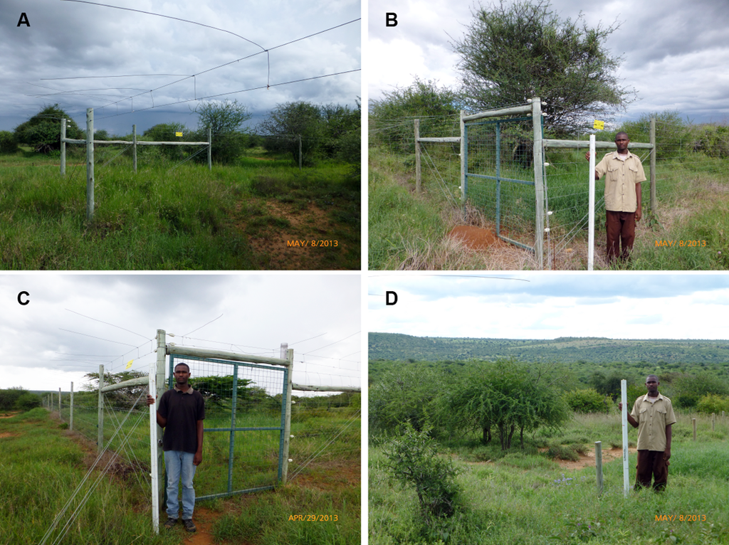

Pictures of 4 experimental treatments. (A) Megaherbivore fences consist of two parallel wires starting 2-m above ground level. (B) Mesoherbivore fences consist of 11 parallel wires starting ~0.3 m above ground level and continuing to 2.4-m above ground level. (C) Total-exclusion fences consist of 14 wires up to 2.4-m above ground level, with a 1-m high chain-link barrier at ground level. (D) Open control plots are unfenced, with boundaries demarcated by short wooden posts at 10-m intervals.

- So far we’ve been working with datasets that are built into R, or making our own small data sets within our scripts.
- Now we will need to read in the datasets into R.
- But first, take a look at the `uhuru_acacia_lab2.txt` and `uhuru_tree_lab2.txt` datasets by opening them.
- - *Click on Acacia Dataset to Open in Text Editor*
- This data is tab separated, so we’ll need to tell that to R so it will be read in correctly.
- - The other, more common form of storing data is in a `.csv`, or comma separated table. We will go over how to read those file types into R later in the course.
- To do this we manually set the character separating each column using the optional `sep` argument
- So we’ll call our data frame `acacia` and assign it the output from `read.csv`
- We still give it the name of the file in quotes as the first argument
- Then we add a comma and `sep = "\t"`
- `\t` is who we indicate a Tab character in programming

```r
acacia <- read.csv("data/uhuru_acacia_lab2.txt", sep="\t")
```

Whenever you load a dataset into R, it is always a good idea to take a look at it to familiarize yourself with the structure. Run the following lines of code in RStudio (I have removed the output to save space here):

```r
names(acacia)
head(acacia)
tail(acacia)
str(acacia)
summary(acacia)
```

- We can also see that it includes information on whether or not the plant is dead in the HEIGHT column
- Is that good data structure?
- If you said “No”, you’re right, information on if the tree is dead should be stored in a separate column
- For now, we’ll just treat the “dead” entries as null values
- We can do this by using another optional argument `na.strings`
- So let’s modify our `read.csv` statement by adding `na.strings = c("dead")`.
- This will replace the string `"dead"` with `NA`
- It gets passed as a vector because this allows multiple different values to be set as nulls

```r
acacia <- read.csv("data/uhuru_acacia_lab2.txt", sep="\t", na.strings = c("dead"))
```

- If we open the resulting table we can see that it includes information on:
  - the time and location of the sampling
  - the experimental treatment
  - the size of each Acacia including a height, the canopy diameter measured in the direction (or axis) or the largest diameter and the diameter of the axis perpendicular to that, and the circumference of the shrub
  - information on the number of flowers, buds, and fruits
  - And finally information on the species of ant associated with the shrub because there is a very interesting ant-acacia mutualism where the Acacia special structures that serve as houses for the ants and the ants swarm herbivores that try to eat the acacia

### ggplot

- Very popular plotting package
- Good plots quickly
- Declarative - describe what you want not how to build it
- Contrasts w/Imperative - how to build it step by step
- Install `ggplot2` using `install.packages`

### Basics

- We load the `ggplot2` package just like we loaded `dplyr`

```r
library(ggplot2)
```

- We’ll also load the UHURU like we discussed in the video on the dataset

```r
acacia <- read.csv("ACACIA_DREPANOLOBIUM_SURVEY.txt", sep="\t", na.strings = c("dead"))
```

- To build a plot using `ggplot` we start with the `ggplot()` function

```r
ggplot()
```

- `ggplot()` creates a base ggplot object that we can then add things to
- Like a blank canvas
- We can also add optional arguments for information to be shared across different components of the plot
- The two main arguments we typically use here are
- `data` - which is the name of the data frame we are working with, so `acacia`
- `mapping` - which describes which columns of the data are used for different aspects of the plot
- We create a `mapping` by using the `aes` function, which stands for “aesthetic”, and then linking columns to pieces of the plot
- We’ll start with telling ggplot what value should be on the x and y axes
- Let’s plot the relationship betwen the circumference of an acacia and its height

```r
ggplot(data = acacia, mapping = aes(x = CIRC, y = HEIGHT))
```

- This still doesn’t create a figure, it’s just a blank canvas and some information on default values for data and mapping columns to pieces of the plot
- We can add data to the plot using layers
- We do this by adding a `+` after the the `ggplot` function and then adding something called a `geom`, which stands for `geometry`
- To make a scatter plot we use `geom_point`

```r
ggplot(data = acacia, mapping = aes(x = CIRC, y = HEIGHT)) +
  geom_point()
```

- It is standard to hit `Enter` after the plus so that each layer shows up on its own line
- To change things about the layer we can pass additional arguments to the `geom`
- We can do things like change
  - the `size` of the points, we’ll set it to `3`
  - the `color` of the points, we’ll set it to `"blue"`
  - the transparency of the points, which is called `alpha`, we’ll set it to 0.5

```r
ggplot(data = acacia, mapping = aes(x = CIRC, y = HEIGHT)) +
  geom_point(size = 3, color = "blue", alpha = 0.5)
```

- To add labels (like documentation for your graphs!) we use the `labs` function

```r
ggplot(data = acacia, mapping = aes(x = CIRC, y = HEIGHT)) +
  geom_point(size = 3, color = "blue", alpha = 0.5) +
  labs(x = "Circumference [cm]", y = "Height [m]",
       title = "Acacia Survey at UHURU")
```

### Rescaling axes

```r
ggplot(data = acacia, mapping = aes(x = CIRC, y = HEIGHT)) +
  geom_point(size = 3, color = "blue", alpha = 0.5) +
  scale_y_log10() +
  scale_x_log10()
```

- Not changing the data itself, just the presentation of it

> Do Tasks 1-2 in Acacia and ants.

### Grouping

- Group on a single graph
- Look at influence of experimental treatment

```r
ggplot(acacia, aes(x = CIRC, y = HEIGHT, color = TREATMENT)) +
  geom_point(size = 3, alpha = 0.5)
```

- Facet specification

```r
ggplot(acacia, aes(x = CIRC, y = HEIGHT)) +
  geom_point(size = 3, alpha = 0.5) +
  facet_wrap(~TREATMENT)
```

> Do Tasks 3-4 in Acacia and ants.

### Statistical transformations

- We’ve seen that ggplot makes graphs by combining information on
  - Data
  - Mapping of parts of that data to aspects of the plot
  - A geometric object to represent the data

```r
ggplot(acacia, aes(x = CIRC, y = HEIGHT)) +
  geom_point()
```

- Many kinds of geometric object (type `geom_` and show completions)
- Each geom includes a statistical transformations
- So far we’ve only seen
  - `identity`: the raw form of the data or no transformation
- Transformations exist to make things like histograms, bar plots, etc.
- Occur as defaults in associated geoms
- To look at the number of acacia in each treatment use a bar plot
  - [`geom_bar()`](https://ggplot2.tidyverse.org/reference/geom_bar.html)

```r
ggplot(acacia, aes(x = TREATMENT)) +
  geom_bar()
```

- Uses the transformation `stat_count()`
  - Counts the number of rows for each treatment
- To look at the distribution of circumferences in the dataset use a histogram
  - [`geom_histogram()`](https://ggplot2.tidyverse.org/reference/geom_histogram.html)

```r
ggplot(acacia, aes(x = CIRC)) +
  geom_histogram(fill = "red")
```

- Uses `stat_bins()` for data transformation
  - Splits circumferences into bins and counts rows in each bin
- Set number of `bins` or `binwidth`

```r
ggplot(acacia, aes(x = CIRC)) +
  geom_histogram(fill = "red", bins = 15)
```

```r
ggplot(acacia, aes(x = CIRC)) +
  geom_histogram(fill = "red", binwidth = 5)
```

- These can be combined with all of the other `ggplot2` features we’ve learned

> Do Tasks 1-2 in Acacia and ants histograms.

### Position

- geom’s also come with a default position
- In many cases the position is `"identity"`, which just means the object is plotted in the position determined by the data, but not always
- Let’s remake our histogram, but color the bars by the treatment

```r
ggplot(acacia, aes(x = CIRC, color = TREATMENT)) +
  geom_histogram(binwidth = 5)
```

```r
ggplot(acacia, aes(x = CIRC, color = TREATMENT)) +
  geom_histogram(binwidth = 5, position = "identity")
```

- And then add some transparency so we can see all of the histograms

```r
ggplot(acacia, aes(x = CIRC, color = TREATMENT)) +
  geom_histogram(binwidth = 5, position = "identity", alpha = 0.5)
```

### Layers

- So far we’ve only plotted one layer or geom at a time, but we can combine multiple layers in a single plot
  - `ggplot()` sets defaults for all layers
  - Can combine multiple layers using `+`
  - The first geom is plotted first and then additional geoms are layered on top
- Combine different kinds of layers
- Add a linear model

```r
ggplot(acacia, aes(x = CIRC, y = HEIGHT)) +
  geom_point() +
  geom_smooth(method = "lm")
```

- Both the `geom_point` layer and the `geom_smooth` layer use the defaults form `ggplot`
- Both use `acacia` for data and `x = CIRC, y = HEIGHT` for the aesthetic
- `geom_smooth` uses the statistical transformation `stat_smooth()` to produce a smoothed representation of the data
- Do this by treatment

```r
ggplot(acacia, aes(x = CIRC, y = HEIGHT, color = TREATMENT)) +
  geom_point() +
  geom_smooth(method = "lm")
```

- Because the color aesthetic is the default it is inherited by geom_smooth
- One set of points and one model for each treatment

### Changing values across layers

- We can also plot data from different columns or even data frames on the same graph
- To do this we need to better understand how layers and defaults work
- So far we’ve put all of the information on data and aesthetic mapping into `ggplot()`

```r
ggplot(data = acacia, mapping = aes(x = CIRC, y = HEIGHT)) +
  geom_point() +
  geom_smooth(method = "lm")
```

```r
ggplot() +
  geom_point(data = acacia,
             mapping = aes(x = CIRC, y = HEIGHT,
                           color = TREATMENT)) +
  geom_smooth(method = "lm")
```

```r
ggplot() +
  geom_point(data = acacia,
             mapping = aes(x = CIRC, y = HEIGHT,
                           color = TREATMENT)) +
  geom_smooth(data = acacia,
              mapping = aes(x = CIRC, y = HEIGHT))
```

- `color` is only set in the aesthethic for the point layer
- So the smooth layer is made across all x and y values
- *Check if this makes sense to everyone*
- This same sort of change can be used to plot different columns on the same plot by changing the values of x or y
- If we wanted to plot two different columns as Y we could change the value of y in the aesthetic
- If we wanted to use data from two different data frames we could change the value of data
- We can also keep all of the values that are shared as defaults if we want to

```r
ggplot(data = acacia, mapping = aes(x = CIRC, y = HEIGHT)) +
  geom_point(mapping = aes(color = TREATMENT)) +
  geom_smooth(method = "lm")
```

> Do Task 3 in Acacia and ants histograms.

### Grammar of graphics

- Uniquely describe any plot based on a defined set of information
- Leland Wilkinson
- Geometric object(s)
  - Data
  - Mapping
  - Statistical transformation
  - Position (allows you to shift objects, e.g., spread out overlapping data points)
- Facets
- Coordinates (coordinate systems other than cartesian, also allows zooming)

### Saving plots as new files

```r
ggsave("acacia_by_treatment.jpg")
```

- The type of the file is determined by the file extension

```r
ggsave("acacia_by_treatment.pdf")
```

- Lots of optional arguments including size

```r
ggsave("acacia_by_treatment.pdf", height = 5, width = 5)
```

> Assign the rest of the exercises.